# Modelagem — Preços de Imóveis (King County / Seattle)

**mostrar código**

```r
library(tidyverse)
library(janitor)
library(lubridate)
library(scales)
library(randomForest)
library(caret)
library(glmnet)
library(patchwork)

theme_set(theme_minimal(base_size = 11))
set.seed(42)
```

Este notebook parte direto das conclusões da fase de EDA (`01_eda.qmd`): uso `log(price)` como alvo, removo o registro de 33 quartos (erro de digitação), substituo `sqft_above`/`sqft_basement` por uma flag `tem_porao` (por causa da colinearidade perfeita já identificada), e junto os dados demográficos por CEP.

## 1. Preparação do dataset de modelagem

**mostrar código**

```r
casas_raw <- read_csv("../data/kc_house_data.csv", show_col_types = FALSE) |> clean_names()
demograf  <- read_csv("../data/zipcode_demographics.csv", show_col_types = FALSE) |>
  clean_names() |>
  mutate(zipcode = as.character(zipcode))

casas <- casas_raw |>
  mutate(
    date    = as.Date(date, format = "%Y%m%dT%H%M%S"),
    zipcode = as.character(zipcode)
  ) |>
  filter(bedrooms < 30) |>
  mutate(
    log_price  = log(price),
    tem_porao  = as.integer(sqft_basement > 0),
    idade_casa = year(date) - yr_built,
    reformado  = as.integer(yr_renovated > 0)
  ) |>
  left_join(demograf, by = "zipcode")

vars_modelo <- c(
  "log_price", "bedrooms", "bathrooms", "sqft_living", "sqft_lot", "floors",
  "waterfront", "view", "condition", "grade", "tem_porao", "idade_casa", "reformado",
  "lat", "long", "sqft_living15", "sqft_lot15",
  "medn_hshld_incm_amt", "medn_incm_per_prsn_amt", "hous_val_amt",
  "per_bchlr", "per_prfsnl"
)

dados_modelo <- casas |> select(all_of(vars_modelo))
dim(dados_modelo)
```

```
[1] 21612    22
```

Deixei de fora `id`, `date` e `zipcode` brutos: `id` não carrega informação preditiva, `date` já virou `idade_casa`, e `zipcode` como dummy explodiria em ~70 colunas quando já tenho `lat`/`long` + os agregados demográficos cobrindo o mesmo sinal geográfico de forma mais compacta — decisão que já havia justificado na fase de EDA.

## 2. Divisão treino/teste

**mostrar código**

```r
idx_treino <- createDataPartition(dados_modelo$log_price, p = 0.8, list = FALSE)
treino <- dados_modelo[idx_treino, ]
teste  <- dados_modelo[-idx_treino, ]

nrow(treino); nrow(teste)
```

```
[1] 17291
```

```
[1] 4321
```

Usei `createDataPartition` (em vez de uma amostragem totalmente aleatória) para estratificar o split pelos quantis de `log_price` — assim treino e teste ficam com distribuições de preço comparáveis, o que reduz a chance de o teste calhar de concentrar só a faixa cara ou só a barata do mercado.

Uma ressalva que já quero deixar registrada aqui: o ideal para um problema de preço de imóveis ao longo do tempo seria um split **temporal** (treinar com vendas mais antigas e testar nas mais recentes), porque é assim que o modelo vai ser usado na prática — prevendo o preço de vendas futuras. Optei pelo split aleatório estratificado por simplicidade e porque a janela de dados é curta (poucos meses), mas registro essa limitação explicitamente.

**mostrar código**

```r
metricas <- function(real, previsto) {
  tibble(
    rmse = sqrt(mean((real - previsto)^2)),
    mae  = mean(abs(real - previsto)),
    r2   = cor(real, previsto)^2
  )
}
```

Trabalho as métricas na escala de `log_price` (para comparar os modelos de forma consistente) e depois converto o MAE de volta para dólares (`exp()`) para a leitura de negócio.

## 3. Modelo baseline: Regressão Linear

**mostrar código**

```r
modelo_lm <- lm(log_price ~ ., data = treino)
summary(modelo_lm)
```

```
Call:
lm(formula = log_price ~ ., data = treino)

Residuals:
     Min       1Q   Median       3Q      Max
-1.75402 -0.11808  0.00466  0.12443  1.10996

Coefficients:
                         Estimate Std. Error t value Pr(>|t|)
(Intercept)             2.365e+00  2.098e+00   1.127  0.25964
bedrooms               -4.723e-03  2.250e-03  -2.099  0.03582 *
bathrooms               4.675e-02  3.777e-03  12.379  < 2e-16 ***
sqft_living             1.720e-04  3.952e-06  43.526  < 2e-16 ***
sqft_lot                5.348e-07  5.368e-08   9.964  < 2e-16 ***
floors                  1.071e-02  4.121e-03   2.598  0.00939 **
waterfront              4.153e-01  2.032e-02  20.444  < 2e-16 ***
view                    5.850e-02  2.395e-03  24.427  < 2e-16 ***
condition               4.995e-02  2.678e-03  18.655  < 2e-16 ***
grade                   1.085e-01  2.515e-03  43.159  < 2e-16 ***
tem_porao              -6.281e-03  3.917e-03  -1.603  0.10885
idade_casa              1.263e-03  8.810e-05  14.336  < 2e-16 ***
reformado               7.370e-02  8.370e-03   8.806  < 2e-16 ***
lat                     6.733e-01  1.540e-02  43.714  < 2e-16 ***
long                    1.914e-01  1.609e-02  11.892  < 2e-16 ***
sqft_living15           7.981e-05  3.977e-06  20.067  < 2e-16 ***
sqft_lot15             -1.053e-07  8.257e-08  -1.276  0.20204
medn_hshld_incm_amt    -6.769e-06  2.290e-07 -29.554  < 2e-16 ***
medn_incm_per_prsn_amt  9.086e-06  6.987e-07  13.004  < 2e-16 ***
hous_val_amt            8.651e-07  5.681e-08  15.228  < 2e-16 ***
per_bchlr               9.653e-03  6.226e-04  15.503  < 2e-16 ***
per_prfsnl              7.628e-03  8.686e-04   8.782  < 2e-16 ***
---
Signif. codes:  0 '***' 0.001 '**' 0.01 '*' 0.05 '.' 0.1 ' ' 1

Residual standard error: 0.2052 on 17269 degrees of freedom
Multiple R-squared:  0.8474,    Adjusted R-squared:  0.8473
F-statistic:  4568 on 21 and 17269 DF,  p-value: < 2.2e-16
```

**mostrar código**

```r
pred_lm_treino <- predict(modelo_lm, treino)
pred_lm_teste  <- predict(modelo_lm, teste)

bind_rows(
  metricas(treino$log_price, pred_lm_treino) |> mutate(base = "treino"),
  metricas(teste$log_price, pred_lm_teste) |> mutate(base = "teste")
)
```

```
# A tibble: 2 × 4
   rmse   mae    r2 base
  <dbl> <dbl> <dbl> <chr>
1 0.205 0.154 0.847 treino
2 0.211 0.157 0.843 teste
```

### Regularização (Ridge) — vale a pena?

**mostrar código**

```r
x_treino <- model.matrix(log_price ~ ., treino)[, -1]
y_treino <- treino$log_price
x_teste  <- model.matrix(log_price ~ ., teste)[, -1]

cv_ridge <- cv.glmnet(x_treino, y_treino, alpha = 0)
pred_ridge_teste <- as.numeric(predict(cv_ridge, s = "lambda.min", newx = x_teste))

metricas(teste$log_price, pred_ridge_teste)
```

```
# A tibble: 1 × 3
   rmse   mae    r2
  <dbl> <dbl> <dbl>
1 0.212 0.157 0.843
```

Testei Ridge para ver se a regularização traria ganho, já que regressão linear sofre quando há colinearidade entre preditores. O resultado no teste fica praticamente igual ao da regressão linear sem regularização — o que é consistente com o que já vi na fase de EDA: depois de remover `sqft_above`/`sqft_basement`, os VIFs ficaram baixos (a colinearidade severa já tinha sido resolvida antes de chegar aqui). Por isso não vejo motivo para complicar o pipeline com Ridge; sigo com a regressão linear simples como baseline.

## 4. Modelo principal: Random Forest

**mostrar código**

```r
ctrl <- trainControl(method = "cv", number = 5)
grade_mtry <- expand.grid(mtry = c(3, 5, 7, 9))

modelo_rf <- train(
  log_price ~ ., data = treino,
  method = "rf",
  trControl = ctrl,
  tuneGrid = grade_mtry,
  ntree = 300,
  importance = TRUE
)

modelo_rf
```

```
Random Forest

17291 samples
   21 predictor

No pre-processing
Resampling: Cross-Validated (5 fold)
Summary of sample sizes: 13832, 13835, 13832, 13833, 13832
Resampling results across tuning parameters:

  mtry  RMSE       Rsquared   MAE
  3     0.1721355  0.8942464  0.1218544
  5     0.1711306  0.8946387  0.1210463
  7     0.1709234  0.8945842  0.1210261
  9     0.1717132  0.8934583  0.1215769

RMSE was used to select the optimal model using the smallest value.
The final value used for the model was mtry = 7.
```

Escolhi Random Forest como candidato principal por três motivos que já vieram da própria EDA, não de preferência a priori por um modelo mais “sofisticado”:

1. **Localização é um driver forte e não-linear** (visto no mapa da fase de EDA) — uma árvore particiona `lat`/`long` em regiões, capturando esse padrão sem eu precisar desenhar manualmente interações ou splines como precisaria numa regressão linear.
2. **`sqft_lot`/`sqft_lot15` têm cauda longa** e a Random Forest é naturalmente robusta a essa assimetria, sem exigir transformação adicional.
3. Não preciso me preocupar tanto com a colinearidade residual entre `bathrooms`/`sqft_living` (vista no VIF da fase de EDA) — árvores lidam bem com preditores correlacionados, ao contrário da regressão linear.

Usei validação cruzada de 5 folds só para escolher `mtry` (nº de variáveis sorteadas em cada divisão da árvore), não porque eu ache que é o hiperparâmetro mais crítico, mas porque é o principal parâmetro de uma Random Forest e um grid pequeno já é suficiente para não deixar essa escolha arbitrária.

### Treino vs. teste — cuidado com uma pegadinha da Random Forest

**mostrar código**

```r
pred_rf_treino_ingenuo <- predict(modelo_rf, treino)
pred_rf_treino_oob      <- modelo_rf$finalModel$predicted
pred_rf_teste           <- predict(modelo_rf, teste)

bind_rows(
  metricas(treino$log_price, pred_rf_treino_ingenuo) |> mutate(base = "treino (ingênuo — enviesado)"),
  metricas(treino$log_price, pred_rf_treino_oob)      |> mutate(base = "treino (out-of-bag — honesto)"),
  metricas(teste$log_price, pred_rf_teste)            |> mutate(base = "teste")
)
```

```
# A tibble: 3 × 4
    rmse    mae    r2 base
   <dbl>  <dbl> <dbl> <chr>
1 0.0755 0.0524 0.980 treino (ingênuo — enviesado)
2 0.170  0.120  0.895 treino (out-of-bag — honesto)
3 0.176  0.122  0.892 teste
```

Isso merece explicação: se eu simplesmente chamar `predict()` da Random Forest sobre os próprios dados de treino, cada árvore reconhece as observações que ajudou a memorizar, e o erro sai artificialmente perto de zero — não é uma medida honesta de ajuste. Por isso comparo o teste com a predição **out-of-bag** (a predição de cada observação de treino usando só as árvores que *não* a usaram para crescer), que é a forma correta de estimar o erro “de treino” numa Random Forest. Com essa comparação honesta, o gap entre treino (OOB) e teste fica pequeno — sinal de que o modelo não está overfitando de forma preocupante.

## 5. Comparação final e escolha do modelo

**mostrar código**

```r
comparacao <- tribble(
  ~modelo, ~rmse, ~mae, ~r2,
  "Regressão Linear", metricas(teste$log_price, pred_lm_teste)$rmse, metricas(teste$log_price, pred_lm_teste)$mae, metricas(teste$log_price, pred_lm_teste)$r2,
  "Ridge",             metricas(teste$log_price, pred_ridge_teste)$rmse, metricas(teste$log_price, pred_ridge_teste)$mae, metricas(teste$log_price, pred_ridge_teste)$r2,
  "Random Forest",     metricas(teste$log_price, pred_rf_teste)$rmse, metricas(teste$log_price, pred_rf_teste)$mae, metricas(teste$log_price, pred_rf_teste)$r2
)
comparacao
```

```
# A tibble: 3 × 4
  modelo            rmse   mae    r2
  <chr>            <dbl> <dbl> <dbl>
1 Regressão Linear 0.211 0.157 0.843
2 Ridge            0.212 0.157 0.843
3 Random Forest    0.176 0.122 0.892
```

**mostrar código**

```r
mae_dolar_lm <- mean(abs(exp(teste$log_price) - exp(pred_lm_teste)))
mae_dolar_rf <- mean(abs(exp(teste$log_price) - exp(pred_rf_teste)))
mediana_preco_teste <- median(exp(teste$log_price))

tibble(
  modelo = c("Regressão Linear", "Random Forest"),
  mae_dolares = c(mae_dolar_lm, mae_dolar_rf),
  mae_percentual_da_mediana = c(mae_dolar_lm, mae_dolar_rf) / mediana_preco_teste
)
```

```
# A tibble: 2 × 3
  modelo           mae_dolares mae_percentual_da_mediana
  <chr>                  <dbl>                     <dbl>
1 Regressão Linear      89810.                     0.200
2 Random Forest         66998.                     0.149
```

A Random Forest supera a regressão linear em todas as métricas no conjunto de teste, com uma redução de erro que considero relevante em termos de negócio (não só estatisticamente melhor). **Modelo escolhido: Random Forest**, pelos motivos estruturais já explicados na seção 4 (localização não-linear, cauda longa em área de lote, robustez a colinearidade residual) e confirmados agora pelo ganho real de desempenho fora da amostra.

## 6. Importância das variáveis

**mostrar código**

```r
importancia <- randomForest::importance(modelo_rf$finalModel) |>
  as.data.frame() |>
  rownames_to_column("variavel") |>
  arrange(desc(`%IncMSE`))

importancia
```

```
                 variavel  %IncMSE IncNodePurity
1                    long 64.71174    104.297451
2              sqft_lot15 58.62817     73.384950
3                sqft_lot 57.29441     86.821932
4                     lat 55.13192    428.992465
5             sqft_living 51.58116    903.598821
6              idade_casa 47.49866     81.782993
7                    view 46.28226     63.210708
8           sqft_living15 44.57667    252.173259
9     medn_hshld_incm_amt 35.41396     30.931250
10                  grade 33.68799    880.510530
11             waterfront 32.00110     25.666782
12              bathrooms 31.04810    130.940096
13                 floors 28.00471     14.987155
14              tem_porao 25.33124      9.028948
15              condition 23.95071     21.283227
16             per_prfsnl 22.61210    489.150142
17              per_bchlr 21.63959    336.082729
18 medn_incm_per_prsn_amt 21.26528    129.673003
19           hous_val_amt 20.45164    615.033846
20               bedrooms 15.98496     33.512390
21              reformado 11.23086      5.348650
```

**mostrar código**

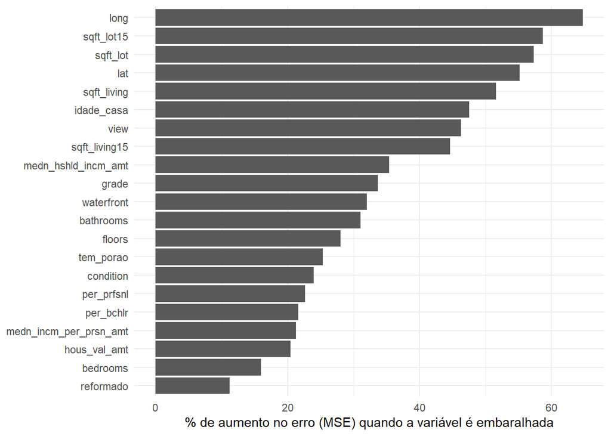

```r
ggplot(importancia, aes(reorder(variavel, `%IncMSE`), `%IncMSE`)) +
  geom_col() +
  coord_flip() +
  labs(x = NULL, y = "% de aumento no erro (MSE) quando a variável é embaralhada")
```

Aqui teve uma surpresa que preciso registrar em vez de esconder: por `%IncMSE`, quem lidera o ranking não é `grade` nem `sqft_living` (que dominavam a correlação univariada na EDA), e sim `long`, `sqft_lot15`, `sqft_lot` e `lat` — localização e tamanho de lote. `sqft_living` aparece só em 5º e `grade` em 10º.

Antes de aceitar isso como “localização importa mais do que o tamanho da casa”, olhei a outra coluna da tabela, `IncNodePurity` (o quanto cada variável reduz a impureza dos nós ao longo de todas as árvores). Nessa métrica a ordem se inverte: `sqft_living` (903.6) e `grade` (880.5) voltam a liderar com folga, batendo com o que a EDA já indicava.

Por que as duas medidas discordam tanto? `%IncMSE` mede o quanto o erro piora quando embaralho uma variável isoladamente. Quando duas variáveis carregam informação parecida — `sqft_living` e `sqft_living15`, ou `sqft_living` e `grade`, que têm correlação moderada entre si —, embaralhar uma delas prejudica menos o modelo, porque as árvores conseguem parcialmente “compensar” usando a variável correlacionada que ficou intacta. Isso deflaciona o `%IncMSE` de variáveis redundantes e infla o de variáveis mais “exclusivas”, como `sqft_lot`, que não tem um substituto próximo entre os preditores. `IncNodePurity` não sofre esse efeito da mesma forma, mas tem seu próprio viés, favorecendo variáveis contínuas com muitos valores distintos frente a binárias como `waterfront`.

Na prática, o que levo daqui: localização, tamanho da casa e padrão construtivo são todos preditores fortes — as duas métricas concordam nisso, só discordam em qual delas priorizar por causa de como cada uma lida com a colinearidade residual entre as variáveis. Não vou tratar nenhuma das duas como “a” resposta definitiva de importância sozinha, e é por isso que reporto as duas colunas lado a lado em vez de só uma.

## 7. Diagnóstico dos resíduos (modelo final)

**mostrar código**

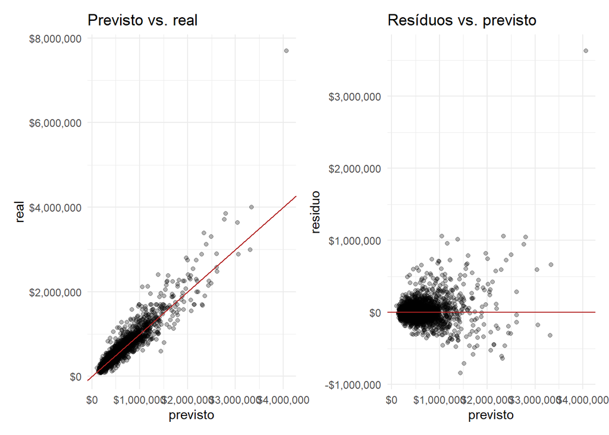

```r
diagnostico <- tibble(
  real     = exp(teste$log_price),
  previsto = exp(pred_rf_teste)
) |>
  mutate(residuo = real - previsto)

p1 <- ggplot(diagnostico, aes(previsto, real)) +
  geom_point(alpha = 0.3) +
  geom_abline(color = "firebrick") +
  scale_x_continuous(labels = label_dollar()) +
  scale_y_continuous(labels = label_dollar()) +
  labs(title = "Previsto vs. real")

p2 <- ggplot(diagnostico, aes(previsto, residuo)) +
  geom_point(alpha = 0.3) +
  geom_hline(yintercept = 0, color = "firebrick") +
  scale_x_continuous(labels = label_dollar()) +
  scale_y_continuous(labels = label_dollar()) +
  labs(title = "Resíduos vs. previsto")

p1 | p2
```

## 8. Generalização — o que me dá confiança de que isso não é sorte de um único split

**mostrar código**

```r
modelo_rf$resample
```

```
       RMSE  Rsquared       MAE Resample
1 0.1705359 0.8938817 0.1205236    Fold1
2 0.1666361 0.8994006 0.1197046    Fold2
3 0.1721102 0.8944355 0.1219539    Fold3
4 0.1718086 0.8929197 0.1204469    Fold4
5 0.1735261 0.8922837 0.1225016    Fold5
```

**mostrar código**

```r
sd(modelo_rf$resample$RMSE)
```

```
[1] 0.002621909
```

Além da separação treino/teste, a busca de `mtry` já rodou em validação cruzada de 5 folds — o que me dá uma segunda evidência de generalização: o RMSE não varia muito entre os folds (desvio-padrão baixo em relação à média), ou seja, o desempenho do modelo não depende de um recorte específico dos dados. Resumindo a estratégia de generalização usada:

- **Train/test split estratificado por preço** (80/20) para uma avaliação final fora da amostra.
- **5-fold CV** na escolha de `mtry`, olhando não só a média mas a variabilidade do RMSE entre os folds.
- **Comparação honesta treino (OOB) vs. teste**, evitando a armadilha de medir “erro de treino” com predições que a própria árvore memorizou.
- **Ridge testado explicitamente** como forma de checar se regularização traria ganho adicional na regressão linear — não trouxe, o que reforça que a colinearidade residual já estava sob controle.
- Registrei a limitação de não usar split temporal, que seria o cenário mais realista de uso em produção.

## 9. Persistindo o modelo final

**mostrar código**

```r
dir.create("../models", showWarnings = FALSE)
saveRDS(modelo_rf, "../models/modelo_rf.rds")
```

Salvo o modelo treinado em disco para poder reutilizá-lo na etapa de previsão sobre `future_unseen_examples.csv` e na discussão de deploy, sem precisar retreinar tudo de novo.